# HAR - Treebag vs Rpart

Luis J. Villalobos

10 de abril de 2016

## Introduction

Using devices such as Jawbone Up, Nike FuelBand, and Fitbit it is now possible to collect a large amount of data about personal activity relatively inexpensively. These type of devices are part of the quantified self movement – a group of enthusiasts who take measurements about themselves regularly to improve their health, to find patterns in their behavior, or because they are tech geeks. One thing that people regularly do is quantify how much of a particular activity they do, but they rarely quantify how well they do it. In this project, your goal will be to use data from accelerometers on the belt, forearm, arm, and dumbell of 6 participants. They were asked to perform barbell lifts correctly and incorrectly in 5 different ways. More information is available from the website here: http://groupware.les.inf.puc-rio.br/har (see the section on the Weight Lifting Exercise Dataset)(Many thanks for the dataset).

Furthermore the intention of this investigation is to compare two simple classification techniques and determine which has greater accuracy without having excesive computations. in particular we are comparing the rpart(recursive partition) method and treebag (Bagged CART) method of the caret package in r. the feature to predict is the class of excercise being executed. that is contained in the “classe” variable.

The training data for this project are available [here](https://d396qusza40orc.cloudfront.net/predmachlearn/pml-training.csv) and the test set [here](https://d396qusza40orc.cloudfront.net/predmachlearn/pml-testing.csv)

**Note**: If you are going to reproduce this document, you must download the datasets before running it.

## Loading and Cleaning the dataset.

After loading the data set we clean and remove variables with missing values in order to use variables that have more information to contribute to the evaluated models. furthermore, the first five variables are related to the identification of the subject and the moment of the day the observation was executed. Those variables were deemed unnecesary for the study.

Given the size of the training set we leave the main test set untouch and create a new test set from the training set. This subpartitioning of the data set gives us cross validation by executing this subsampling of the data at 70% for the training set and 30% for the sub testing set.

```r
 validationSet <- read.csv("pml-testing.csv",na.strings = c("","NA"))
 trainSet <- read.csv("pml-training.csv",na.strings = c("","NA"))

 na_count2 <-sapply(trainSet, function(y) sum(length(which(is.na(y))))>0)
 na_count <- data.frame(na_count2)
 trainSet <- trainSet[,!na_count$na_count2]
 trainSet <- trainSet[,-c(1,2,3,4,5)]
 trainIndex <- createDataPartition(trainSet$classe, p=0.7, list=FALSE)
 trainSet.trainSlice <- trainSet[trainIndex,]
 trainSet.testSlice <- trainSet[-trainIndex,]
```

## Feature Selection

Given the amount of variables with missing values, or with little variability we use a correlation matrix to find and remove those variables that have high correlation (over 0.75) to mantain those that explain in greater measure the variation of the data.

We also checked the proportion of the data in the training set and we detected a higher number of excercises labeled “A”.

```r
 #proportion and useful variables

 summary(trainSet.trainSlice$classe)
```

```
##    A    B    C    D    E
## 3906 2658 2396 2252 2525
```

```r
 M <- cor(trainSet.trainSlice[,-c(1,55)])
 highCor <- findCorrelation(M,cutoff = 0.75)
 trainSet.redTrainSilce <- trainSet.trainSlice[,-highCor]
```

## Model selection

Our second attempt to create a classification tree is using the Bagged CART method (treebag in caret) with default parameters(Bootstrapped (25 reps), the selection of this method was made according to the explanations made in [this other thread](http://stats.stackexchange.com/questions/71779/how-bagging-on-cart-rpart-is-different-from-cart-with-cross-validation).

Another factor that was key to selection was the computational time it took in the computer where it was run to get the results. For that reason we decided not to use a random forest to generate out prediction model.

```r
 fitControl <- trainControl(method="repeatedcv",number = 10,repeats = 10)
 #first attempt
 rpartFit <- train(classe ~ ., data=  trainSet.redTrainSilce,method="rpart",trControl=fitControl)
 predictRpart <- predict(rpartFit,newdata = trainSet.redTrainSilce)
 rpartFit.cmt <- confusionMatrix(predictRpart,trainSet.redTrainSilce$classe)
 predictRpart.test <- predict(rpartFit,newdata = trainSet.testSlice)
 rpartFit.cmt.test <- confusionMatrix(predictRpart.test,trainSet.testSlice$classe)

 #second attempt using treebag
 tbfit <- train(classe ~ ., data = trainSet.redTrainSilce, method="treebag")
 predictTB <- predict(tbfit, newdata = trainSet.redTrainSilce)
 tbfit.cmt <- confusionMatrix(predictTB,trainSet.redTrainSilce$classe)
 predictTB.test <- predict(tbfit, newdata = trainSet.testSlice)
 tbfit.cmt.test <- confusionMatrix(predictTB.test,trainSet.testSlice$classe)
```

## Model comparison and selection

We portray both confusion matrices and also compare their accuracy in order to use one for prediction with the inner test set and validation set.First the rpart model

```
##           Reference
## Prediction    A    B    C    D    E
##          A 3548 1089 1100 1007  555
##          B   91  950   90  404  541
##          C  187  266 1034  310  345
##          D   76  352  172  531  360
##          E    4    1    0    0  724
```

```
##  Accuracy
## 0.4940671
```

At this point we can observe that this configuration is insufficient to analyze the dataset

```
##           Reference
## Prediction    A    B    C    D    E
##          A 1511  456  475  425  257
##          B   32  398   39  212  231
##          C   95  130  444  132  132
##          D   34  155   68  195  158
##          E    2    0    0    0  304
```

```
##  Accuracy
## 0.4846219
```

Thus giving a worse result for the test set.This model has an unbalanced decision tree towards class A, as we can see in the decision tree.

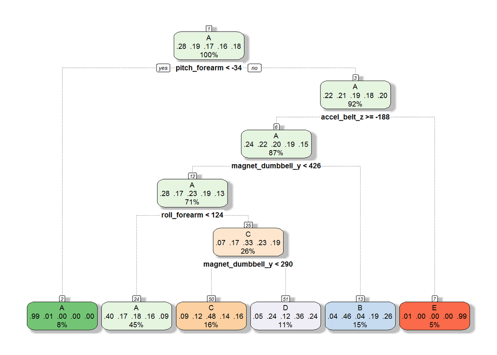

```r
 fancyRpartPlot(rpartFit$finalModel,sub = "",main="")
```

Following the treebag model.

```
##           Reference
## Prediction    A    B    C    D    E
##          A 3906    0    0    0    0
##          B    0 2658    0    0    0
##          C    0    0 2396    0    0
##          D    0    0    0 2252    0
##          E    0    0    0    0 2525
```

```
## Accuracy
##        1
```

It does a better job thanks to the bootstrapping.

```
##           Reference
## Prediction    A    B    C    D    E
##          A 1651   22    2    1    1
##          B   17 1085   15   10    6
##          C    2   23 1002   25    3
##          D    0    6    4  921    5
##          E    4    3    3    7 1067
```

```
##  Accuracy
## 0.9729822
```

## Final Predictions

We decide to use the treebag model to be used over the validation set. With the final result for the prediction.

```
##  [1] B A B A A E D B A A B C B A E E A B B B
## Levels: A B C D E
```

According to the resubstitution and the accuracy of the inner test set data we can expect that the out of sample error will be near the misclassification error in the sub test set, that means that it should be around 0.0270178.